# Project_team3

```r
library(dplyr)
```

```r
library(ggplot2)
library(scales)
```

read data

```r
raw_movies <- read.csv("/Users/cyrusgong/Desktop/NEU/Courses/IE7275/project/raw data/movies_1.csv")
raw_ratings <- read.csv("/Users/cyrusgong/Desktop/NEU/Courses/IE7275/project/raw data/ratings.csv")
```

First, we want to make rankings of best movies in each decade and best movies in each genre. This could do a help for us to understand raw data and be a recourse for us to recommend specific movies to new users in our following model.

Decades best:

```r
# find how many years we have
temp1 <- c()
"%!in%" <- Negate("%in%")  #define a "not in" function

for (i in 1:length(raw_movies$year)){
  if (raw_movies$year[i] %!in% temp1){
    temp1 <- append(raw_movies$year[i], temp1)
  }
}

temp1 <- sort(temp1)
length(temp1)
```

```
## [1] 100
```

```r
# bins: -1920, 10 years an interval, 2011-2015
decade_movie_id <- c()

# 1902-1920
for (i in 1902:1920){
  for (j in 1:length(raw_movies$year)){
    if(i == raw_movies$year[j]){
      decade_movie_id <- append(raw_movies$movieId[j], decade_movie_id)
    }
  }
}

# count number of ratings of each movie id
num_movies <- count(raw_ratings, movieId)

# select movies (in decade_movie_id) and their numbers of ratings between 1902 and 1920
num_ratings <- c()

for (each in decade_movie_id){
  if (length(which(num_movies$movieId == each) != 0)){
    num_ratings = append(c(each, num_movies$n[which(num_movies$movieId == each)]), num_ratings)
  }
  else{
    num_ratings = append(c(each, 0), num_ratings)
  }
}
```

Based on our criteria, only the movies with over 5% numbers of ratings in this decade can be the candidats for best movies.

```r
threshold <- sum(num_ratings[seq(2, length(num_ratings),2)])*0.05
threshold
```

```
## [1] 1.05
```

Only the movies with more than 1.05 ratings can be candidates.

```r
candidates <- c()
for (i in seq(2, length(num_ratings),2)){
  if (num_ratings[i] >= threshold){
    candidates = append(num_ratings[i-1],candidates)
  }
}
candidates
```

```
## [1]  6987  6988  7065 32898
```

Compute average rating score of each candidate

```r
candidates_averating <- c()
for (each in candidates){
 candidates_averating = append(c(each, mean(raw_ratings$rating[which(raw_ratings$movieId == each)])), candidates_averating)
}
candidates_averating
```

```
## [1] 32898.000000     3.750000  7065.000000     2.166667  6988.000000
## [6]     3.250000  6987.000000     3.846154
```

```r
ranks1 <- data.frame(matrix(candidates_averating, nrow=length(candidates_averating)/2, byrow=2))
colnames(ranks1) <- c("movieId", "averating")

# sort by averating
ranks1902 = ranks1[with(ranks1, order(averating, decreasing = T)),]
ranks1902
```

|  | movieId | averating |
| --- | --- | --- |
| 4 | 6987 | 3.846154 |
| 1 | 32898 | 3.750000 |
| 3 | 6988 | 3.250000 |
| 2 | 7065 | 2.166667 |

# compress above process to a function

```r
decade_best <- function(year_s, year_e){
  # select all movieIds in this decade
  decade_movie_id <- c()
  for (i in year_s:year_e){
  for (j in 1:length(raw_movies$year)){
    if(i == raw_movies$year[j]){
      decade_movie_id <- append(raw_movies$movieId[j], decade_movie_id)
     }
    }
  }

  # count number of ratings of each movie id
  num_movies <- count(raw_ratings, movieId)

  # select movies (in decade_movie_id) and their numbers of ratings between year_s and year_e
  num_ratings <- c()

  for (each in decade_movie_id){
    if (length(which(num_movies$movieId == each) != 0)){
     num_ratings = append(c(each, num_movies$n[which(num_movies$movieId == each)]), num_ratings)
   }
   else{
     num_ratings = append(c(each, 0), num_ratings)
    }
  }

  # threshold for candidates
  threshold <- min(10, sum(num_ratings[seq(2, length(num_ratings), 2)])*0.05)

  candidates <- c()
  for (i in seq(2, length(num_ratings),2)){
    if (num_ratings[i] >= threshold){
      candidates = append(num_ratings[i-1],candidates)
    }
  }

  candidates_averating <- c()
  for (each in candidates){
  candidates_averating = append(c(each, mean(raw_ratings$rating[which(raw_ratings$movieId == each)])), candidates_averating)
  }
  ranks <- data.frame(matrix(candidates_averating, nrow=length(candidates_averating)/2, byrow=2))
  colnames(ranks) <- c("movieId", "averating")

  # sort by averating
  ranks = ranks[with(ranks, order(averating, decreasing = T)),]
  return(ranks)
}
```

```r
decade_best(1931,1940)
```

|  | movieId | averating |
| --- | --- | --- |
| 5 | 8228 | 4.346154 |
| 12 | 945 | 4.307692 |
| 1 | 1260 | 4.261905 |
| 26 | 928 | 4.173913 |
| 10 | 905 | 4.113636 |
| 13 | 965 | 4.108696 |
| 21 | 919 | 4.090090 |
| 30 | 3095 | 4.078947 |
| 20 | 955 | 4.029412 |
| 2 | 2644 | 4.000000 |

[output cut: 20 more lines]

# visualization: plot top 10 in each decade with boxplots

```r
# define a function to select top 10 movieIds
top10_y <- function(year_s, year_r){
  df = decade_best(year_s, year_r)
  return(c(df[["movieId"]][1:min(10,length(df[,1]))]))
}


# define a function to a new dataframe to store top10 movieId, movie names and their ratings
build_df_y <- function(year_s, year_e){
  df <- data.frame()
  for (each in top10_y(year_s, year_e)){
    temp <- data.frame("movieId" = each,
                       "moviename" = raw_movies$title[which(raw_movies$movieId == each)],
                       "rating" = raw_ratings$rating[which(raw_ratings$movieId == each)])
    df <- rbind(df, temp)
  }
return(df)
}

# define a function to build boxplots
top10_box_y <- function(year_s, year_e){
  box <- ggplot(data = build_df_y(year_s,year_e), aes(x=moviename, y=rating, color = moviename)) +
  geom_boxplot() +
  theme(axis.text.x=element_blank())+
  ggtitle(paste("Best movies between",year_s,"and",year_e))

  return(box)
}
```

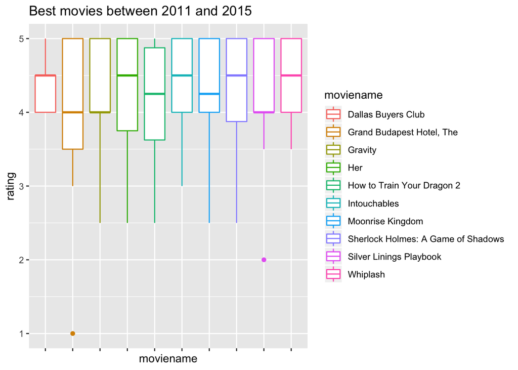

```r
top10_box_y(2011,2015)
```

# best movies in a genre

Create dummies for genres

```r
list_genre <- c("Action", "Adventure", "Animation", "Children",
                "Comedy", "Crime","Documentary", "Drama", "Fantasy",
                "Film-Noir", "Horror", "Musical", "Mystery","Romance",
                "Sci-Fi", "Thriller", "War", "Western")

# add dummy' columns first
movies_dummy <- raw_movies
for (each in list_genre){
  movies_dummy[as.character(each)] <- rep(0, length(movies_dummy$movieId))
}

# create dummies
for (i in 1:length(movies_dummy$movieId)){
  for (j in 1:length(list_genre)){
    if (list_genre[j] %in% sapply(movies_dummy[i,][4:12], as.character)){
      movies_dummy[i,][12+j] = 1
    }
  }
}
```

```r
genre_best <- function(genre){
  # select all movieIds in this genre
  genre_movie_id <- c()
  for (i in 1:length(movies_dummy$movieId)){
    if (movies_dummy[i,][genre] == 1){
      genre_movie_id <- append(movies_dummy$movieId[i], genre_movie_id)
     }
  }

  # count number of ratings of each movie id
  num_movies <- count(raw_ratings, movieId)

  # select movies (in genre_movie_id) and their numbers of ratings in genre
  num_ratings <- c()

  for (each in genre_movie_id){
    if (length(which(num_movies$movieId == each) != 0)){
     num_ratings = append(c(each, num_movies$n[which(num_movies$movieId == each)]), num_ratings)
   }
   else{
     num_ratings = append(c(each, 0), num_ratings)
    }
  }

  # threshold for candidates
  threshold <- min(10, sum(num_ratings[seq(2, length(num_ratings), 2)])*0.05)

  candidates <- c()
  for (i in seq(2, length(num_ratings),2)){
    if (num_ratings[i] >= threshold){
      candidates = append(num_ratings[i-1],candidates)
    }
  }

  candidates_averating <- c()
  for (each in candidates){
  candidates_averating = append(c(each, mean(raw_ratings$rating[which(raw_ratings$movieId == each)])), candidates_averating)
  }
  ranks <- data.frame(matrix(candidates_averating, nrow=length(candidates_averating)/2, byrow=2))
  colnames(ranks) <- c("movieId", "averating")

  # sort by averating
  ranks = ranks[with(ranks, order(averating, decreasing = T)),]
  return(ranks)
}
```

```r
# define a function to select top 10 movieIds
top10_g <- function(genre){
  df = genre_best(genre)
  return(c(df[["movieId"]][1:min(10,length(df[,1]))]))
}


# define a function to a new dataframe to store top10 movieId, movie names and their ratings
build_df_g <- function(genre){
  df <- data.frame()
  for (each in top10_g(genre)){
    temp <- data.frame("movieId" = each,
                       "moviename" = raw_movies$title[which(raw_movies$movieId == each)],
                       "rating" = raw_ratings$rating[which(raw_ratings$movieId == each)])
    df <- rbind(df, temp)
  }
return(df)
}

# define a function to build boxplots
top10_box_g <- function(genre){
  box <- ggplot(data = build_df_g(genre), aes(x=moviename, y=rating, color = moviename)) +
  geom_boxplot() +
  theme(axis.text.x=element_blank())+
  ggtitle(paste("Best", genre, "movies"))

  return(box)
}
```

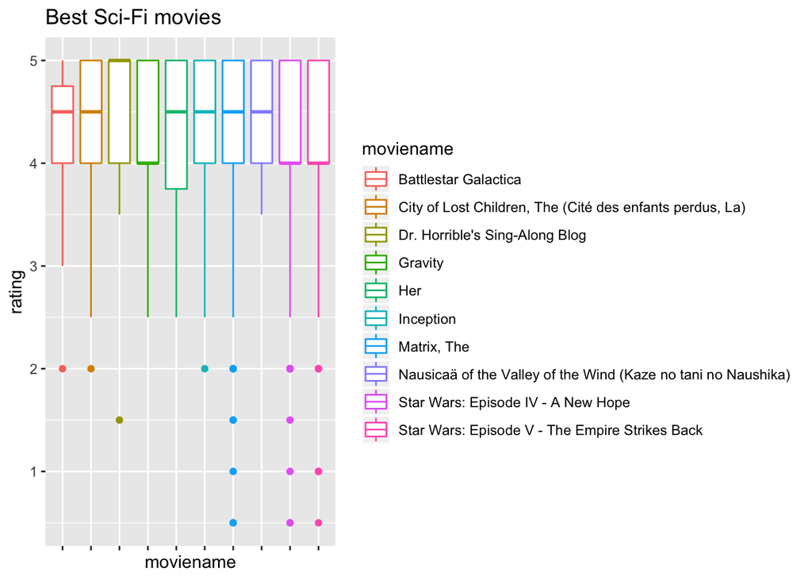

```r
top10_box_g("Sci-Fi")
```

## We can take above information as reference recommendations for new users who don’t have any rating history.

# Recommendation system for new users

input: genres, years (we offer options) output: 5 recommended movies

priority: genres > years

logic: check the intersections of genres and years selected, return top 5 movies with highest ratings; if no enough movies in the intersection, relax years to +- 1 year; if still no, +- 2 years;

```r
decade_best(1930,1940)
```

|  | movieId | averating |
| --- | --- | --- |
| 1 | 1927 | 4.500000 |
| 7 | 8228 | 4.346154 |
| 14 | 945 | 4.307692 |
| 3 | 1260 | 4.261905 |
| 28 | 928 | 4.173913 |
| 12 | 905 | 4.113636 |
| 15 | 965 | 4.108696 |
| 23 | 919 | 4.090090 |
| 32 | 3095 | 4.078947 |
| 22 | 955 | 4.029412 |

[output cut: 22 more lines]

```r
temp.df <- data.frame("movieId" = integer(), "moviename" = character(), "rating" = double())
temp.df<- add_row(temp.df, movieId = 4, moviename= "apd", rating = 5)
```

## run this function for new users

```r
# function to return movie names by movie IDs
movies_return <- function(movieid_list, genre){
  temp.df <- data.frame("movieId" = integer(), "moviename" = character(), "rating" = double())
  for (each in movieid_list){
    temp.df<- add_row(temp.df, movieId = each, moviename = raw_movies$title[which(raw_movies$movieId == each)] , rating = genre_best(genre)$averating[which(genre_best(genre)$movieId == each)])

  }
  return(temp.df)
}


# function to find top 5 in the intersection of selected genre and period
top5_its <- function(genre, year_s, year_e){
  temp_g <- genre_best(genre)
  temp_y <- decade_best(year_s, year_e)
  temp_its <- intersect(temp_g, temp_y)

  # check whether we have 5 movies in the intersection
  if (length(temp_its$movieId) >= 5){
    top5_id = c(temp_its[,1][1:5])
    top5 = movies_return(top5_id, genre)
    return(top5)
  }
  # if no 5 movies, we select relax +- one year
  else{
    top5_its(genre, year_s-1, year_e+1)
  }
}


# recommendation top 5 for new users
new_recom <- function(){

  # starter

  cat("Hi, friend, so glad to have you here.
  Want some movies but don't know which one to start? Let us help you.
  Based on your preferences, we will offer you some amazing movies.
  Hope you enjoy it.
  Let's go!\n")

  cat("\n Let's begin by telling us your favorite genre.\n")
  cat("Please select one of following genres:\n")
  cat(list_genre, sep = ", ")
  favgenre <- readline(prompt = "Your favorite genre is: ")

  cat("Now, tell us your prefered released time of movies. Please select start and end year from 1902 to 2015.")
  favperiod_s <- readline(prompt = "Your favorite period is from: ")
  favperiod_e <- readline(prompt = "to: ")


  # pick the top 5 rated movies in the intersection
  top5_its(favgenre, favperiod_s, favperiod_e)
}
```

# We use 3 varaibles for each genre to denote a user’s watching history: # movies watched, mean/mode of the ratings, mode of years of the movies

Build the data frame to store above information:

```r
temp_name <- c("userId")

for (i in list_genre){
  for (j in c("number", "rating", "year")){   # number: # movies watched; rating: mean of the ratings; year: mode of years of the movies.
    each = paste(i,j,sep = "-")
    temp_name = append(temp_name, each)
  }
}

user_info <- data.frame(matrix(ncol = 55, nrow = 1))
colnames(user_info) <- temp_name

# fill in userids into user_info
for (i in unique(raw_ratings$userId)){
  user_info[i,][1] = i
}

user_info
```

|  | userId | Action-number | Action-rating | Action-year | Adventure-number | Adventure-rating | Adventure-year | Animation-number | Animation-rating | Animation-year | Children-number | Children-rating | Children-year | Comedy-number | Comedy-rating | Comedy-year | Crime-number | Crime-rating | Crime-year | Documentary-number | Documentary-rating | Documentary-year | Drama-number | Drama-rating | Drama-year | Fantasy-number | Fantasy-rating | Fantasy-year | Film-Noir-number | … |
| --- | --- | --- | --- | --- | --- | --- | --- | --- | --- | --- | --- | --- | --- | --- | --- | --- | --- | --- | --- | --- | --- | --- | --- | --- | --- | --- | --- | --- | --- | --- |
| 1 | 1 | NA | NA | NA | NA | NA | NA | NA | NA | NA | NA | NA | NA | NA | NA | NA | NA | NA | NA | NA | NA | NA | NA | NA | NA | NA | NA | NA | NA | … |
| NA | 2 | NA | NA | NA | NA | NA | NA | NA | NA | NA | NA | NA | NA | NA | NA | NA | NA | NA | NA | NA | NA | NA | NA | NA | NA | NA | NA | NA | NA | … |
| 3 | 3 | NA | NA | NA | NA | NA | NA | NA | NA | NA | NA | NA | NA | NA | NA | NA | NA | NA | NA | NA | NA | NA | NA | NA | NA | NA | NA | NA | NA | … |
| 4 | 4 | NA | NA | NA | NA | NA | NA | NA | NA | NA | NA | NA | NA | NA | NA | NA | NA | NA | NA | NA | NA | NA | NA | NA | NA | NA | NA | NA | NA | … |
| 5 | 5 | NA | NA | NA | NA | NA | NA | NA | NA | NA | NA | NA | NA | NA | NA | NA | NA | NA | NA | NA | NA | NA | NA | NA | NA | NA | NA | NA | NA | … |
| 6 | 6 | NA | NA | NA | NA | NA | NA | NA | NA | NA | NA | NA | NA | NA | NA | NA | NA | NA | NA | NA | NA | NA | NA | NA | NA | NA | NA | NA | NA | … |
| 7 | 7 | NA | NA | NA | NA | NA | NA | NA | NA | NA | NA | NA | NA | NA | NA | NA | NA | NA | NA | NA | NA | NA | NA | NA | NA | NA | NA | NA | NA | … |
| 8 | 8 | NA | NA | NA | NA | NA | NA | NA | NA | NA | NA | NA | NA | NA | NA | NA | NA | NA | NA | NA | NA | NA | NA | NA | NA | NA | NA | NA | NA | … |
| 9 | 9 | NA | NA | NA | NA | NA | NA | NA | NA | NA | NA | NA | NA | NA | NA | NA | NA | NA | NA | NA | NA | NA | NA | NA | NA | NA | NA | NA | NA | … |
| 10 | 10 | NA | NA | NA | NA | NA | NA | NA | NA | NA | NA | NA | NA | NA | NA | NA | NA | NA | NA | NA | NA | NA | NA | NA | NA | NA | NA | NA | NA | … |

[output cut: 658 more lines]

Define a function to find the genre based on movieID:

```r
find_genre <- function(movieid){
  temp = which(movies_dummy$movieId == movieid)
  return(movies_dummy[temp,][13:30])
}
find_genre(1)[,1]
```

```
## [1] 0
```

Fill in user_info

```r
# define a function to get the mode
getmode <- function(v) {
   uniqv <- unique(v)
   uniqv[which.max(tabulate(match(v, uniqv)))]
}

# fill in the data frame
for (i in unique(raw_ratings$userId)){
  # fill in # movies watched into user_info
  temp <- raw_ratings$movieId[which(raw_ratings$userId == i)]

  user_info[which(user_info$userId==i),2] <- sum(movies_dummy[,13][which(movies_dummy$movieId %in% temp)])
  user_info[which(user_info$userId==i),5] <- sum(movies_dummy[,14][which(movies_dummy$movieId %in% temp)])
  user_info[which(user_info$userId==i),8] <- sum(movies_dummy[,15][which(movies_dummy$movieId %in% temp)])
  user_info[which(user_info$userId==i),11] <- sum(movies_dummy[,16][which(movies_dummy$movieId %in% temp)])
  user_info[which(user_info$userId==i),14] <- sum(movies_dummy[,17][which(movies_dummy$movieId %in% temp)])
  user_info[which(user_info$userId==i),17] <- sum(movies_dummy[,18][which(movies_dummy$movieId %in% temp)])
  user_info[which(user_info$userId==i),20] <- sum(movies_dummy[,19][which(movies_dummy$movieId %in% temp)])
  user_info[which(user_info$userId==i),23] <- sum(movies_dummy[,20][which(movies_dummy$movieId %in% temp)])
  user_info[which(user_info$userId==i),26] <- sum(movies_dummy[,21][which(movies_dummy$movieId %in% temp)])
  user_info[which(user_info$userId==i),29] <- sum(movies_dummy[,22][which(movies_dummy$movieId %in% temp)])
  user_info[which(user_info$userId==i),32] <- sum(movies_dummy[,23][which(movies_dummy$movieId %in% temp)])
  user_info[which(user_info$userId==i),35] <- sum(movies_dummy[,24][which(movies_dummy$movieId %in% temp)])
  user_info[which(user_info$userId==i),38] <- sum(movies_dummy[,25][which(movies_dummy$movieId %in% temp)])
  user_info[which(user_info$userId==i),41] <- sum(movies_dummy[,26][which(movies_dummy$movieId %in% temp)])
  user_info[which(user_info$userId==i),44] <- sum(movies_dummy[,27][which(movies_dummy$movieId %in% temp)])
  user_info[which(user_info$userId==i),47] <- sum(movies_dummy[,28][which(movies_dummy$movieId %in% temp)])
  user_info[which(user_info$userId==i),50] <- sum(movies_dummy[,29][which(movies_dummy$movieId %in% temp)])
  user_info[which(user_info$userId==i),53] <- sum(movies_dummy[,30][which(movies_dummy$movieId %in% temp)])


  # fill in average ratings for each genre into user_info
  temp1 <- intersect(temp, movies_dummy$movieId[which(movies_dummy$Action == 1)])
  temp2 <- intersect(temp, movies_dummy$movieId[which(movies_dummy$Adventure == 1)])
  temp3 <- intersect(temp, movies_dummy$movieId[which(movies_dummy$Animation == 1)])
  temp4 <- intersect(temp, movies_dummy$movieId[which(movies_dummy$Children == 1)])
  temp5 <- intersect(temp, movies_dummy$movieId[which(movies_dummy$Comedy == 1)])
  temp6 <- intersect(temp, movies_dummy$movieId[which(movies_dummy$Crime == 1)])
  temp7 <- intersect(temp, movies_dummy$movieId[which(movies_dummy$Documentary == 1)])
  temp8 <- intersect(temp, movies_dummy$movieId[which(movies_dummy$Drama == 1)])
  temp9 <- intersect(temp, movies_dummy$movieId[which(movies_dummy$Fantasy == 1)])
  temp10 <- intersect(temp, movies_dummy$movieId[which(movies_dummy$`Film-Noir` == 1)])
  temp11 <- intersect(temp, movies_dummy$movieId[which(movies_dummy$Horror == 1)])
  temp12 <- intersect(temp, movies_dummy$movieId[which(movies_dummy$Musical == 1)])
  temp13 <- intersect(temp, movies_dummy$movieId[which(movies_dummy$Mystery == 1)])
  temp14 <- intersect(temp, movies_dummy$movieId[which(movies_dummy$Romance == 1)])
  temp15 <- intersect(temp, movies_dummy$movieId[which(movies_dummy$`Sci-Fi` == 1)])
  temp16 <- intersect(temp, movies_dummy$movieId[which(movies_dummy$Thriller == 1)])
  temp17 <- intersect(temp, movies_dummy$movieId[which(movies_dummy$War == 1)])
  temp18 <- intersect(temp, movies_dummy$movieId[which(movies_dummy$Western == 1)])

  user_info[which(user_info$userId==i),3] <- mean(raw_ratings[,3][which(raw_ratings$movieId %in% temp1)])
  user_info[which(user_info$userId==i),6] <- mean(raw_ratings[,3][which(raw_ratings$movieId %in% temp2)])
  user_info[which(user_info$userId==i),9] <- mean(raw_ratings[,3][which(raw_ratings$movieId %in% temp3)])
  user_info[which(user_info$userId==i),12] <- mean(raw_ratings[,3][which(raw_ratings$movieId %in% temp4)])
  user_info[which(user_info$userId==i),15] <- mean(raw_ratings[,3][which(raw_ratings$movieId %in% temp5)])
  user_info[which(user_info$userId==i),18] <- mean(raw_ratings[,3][which(raw_ratings$movieId %in% temp6)])
  user_info[which(user_info$userId==i),21] <- mean(raw_ratings[,3][which(raw_ratings$movieId %in% temp7)])
  user_info[which(user_info$userId==i),24] <- mean(raw_ratings[,3][which(raw_ratings$movieId %in% temp8)])
  user_info[which(user_info$userId==i),27] <- mean(raw_ratings[,3][which(raw_ratings$movieId %in% temp9)])
  user_info[which(user_info$userId==i),30] <- mean(raw_ratings[,3][which(raw_ratings$movieId %in% temp10)])
  user_info[which(user_info$userId==i),33] <- mean(raw_ratings[,3][which(raw_ratings$movieId %in% temp11)])
  user_info[which(user_info$userId==i),36] <- mean(raw_ratings[,3][which(raw_ratings$movieId %in% temp12)])
  user_info[which(user_info$userId==i),39] <- mean(raw_ratings[,3][which(raw_ratings$movieId %in% temp13)])
  user_info[which(user_info$userId==i),42] <- mean(raw_ratings[,3][which(raw_ratings$movieId %in% temp14)])
  user_info[which(user_info$userId==i),45] <- mean(raw_ratings[,3][which(raw_ratings$movieId %in% temp15)])
  user_info[which(user_info$userId==i),48] <- mean(raw_ratings[,3][which(raw_ratings$movieId %in% temp16)])
  user_info[which(user_info$userId==i),51] <- mean(raw_ratings[,3][which(raw_ratings$movieId %in% temp17)])
  user_info[which(user_info$userId==i),54] <- mean(raw_ratings[,3][which(raw_ratings$movieId %in% temp18)])


  # fill in mode of years into user_info
  user_info[which(user_info$userId==i),4] <- getmode(movies_dummy[,3][which(movies_dummy$movieId %in% temp1)])
  user_info[which(user_info$userId==i),7] <- getmode(movies_dummy[,3][which(movies_dummy$movieId %in% temp2)])
  user_info[which(user_info$userId==i),10] <- getmode(movies_dummy[,3][which(movies_dummy$movieId %in% temp3)])
  user_info[which(user_info$userId==i),13] <- getmode(movies_dummy[,3][which(movies_dummy$movieId %in% temp4)])
  user_info[which(user_info$userId==i),16] <- getmode(movies_dummy[,3][which(movies_dummy$movieId %in% temp5)])
  user_info[which(user_info$userId==i),19] <- getmode(movies_dummy[,3][which(movies_dummy$movieId %in% temp6)])
  user_info[which(user_info$userId==i),22] <- getmode(movies_dummy[,3][which(movies_dummy$movieId %in% temp7)])
  user_info[which(user_info$userId==i),25] <- getmode(movies_dummy[,3][which(movies_dummy$movieId %in% temp8)])
  user_info[which(user_info$userId==i),28] <- getmode(movies_dummy[,3][which(movies_dummy$movieId %in% temp9)])
  user_info[which(user_info$userId==i),31] <- getmode(movies_dummy[,3][which(movies_dummy$movieId %in% temp10)])
  user_info[which(user_info$userId==i),34] <- getmode(movies_dummy[,3][which(movies_dummy$movieId %in% temp11)])
  user_info[which(user_info$userId==i),37] <- getmode(movies_dummy[,3][which(movies_dummy$movieId %in% temp12)])
  user_info[which(user_info$userId==i),40] <- getmode(movies_dummy[,3][which(movies_dummy$movieId %in% temp13)])
  user_info[which(user_info$userId==i),43] <- getmode(movies_dummy[,3][which(movies_dummy$movieId %in% temp14)])
  user_info[which(user_info$userId==i),46] <- getmode(movies_dummy[,3][which(movies_dummy$movieId %in% temp15)])
  user_info[which(user_info$userId==i),49] <- getmode(movies_dummy[,3][which(movies_dummy$movieId %in% temp16)])
  user_info[which(user_info$userId==i),52] <- getmode(movies_dummy[,3][which(movies_dummy$movieId %in% temp17)])
  user_info[which(user_info$userId==i),55] <- getmode(movies_dummy[,3][which(movies_dummy$movieId %in% temp18)])
}

user_info
```

|  | userId | Action-number | Action-rating | Action-year | Adventure-number | Adventure-rating | Adventure-year | Animation-number | Animation-rating | Animation-year | Children-number | Children-rating | Children-year | Comedy-number | Comedy-rating | Comedy-year | Crime-number | Crime-rating | Crime-year | Documentary-number | Documentary-rating | Documentary-year | Drama-number | Drama-rating | Drama-year | Fantasy-number | Fantasy-rating | Fantasy-year | Film-Noir-number | … |
| --- | --- | --- | --- | --- | --- | --- | --- | --- | --- | --- | --- | --- | --- | --- | --- | --- | --- | --- | --- | --- | --- | --- | --- | --- | --- | --- | --- | --- | --- | --- |
| 1 | 1 | 46 | 3.808385 | 2002 | 31 | 3.828638 | 1996 | 2 | 3.823077 | 2001 | 3 | 3.805825 | 1984 | 31 | 3.876258 | 1994 | 31 | 4.052491 | 1995 | 1 | 3.0000000 | 2006 | 45 | 4.043012 | 1994 | 8 | 3.996334 | 2001 | 2 | … |
| NA | 2 | 9 | 3.543215 | 1996 | 10 | 3.603448 | 1996 | 2 | 3.789753 | 1995 | 3 | 3.788783 | 1995 | 11 | 3.687876 | 1995 | 3 | 4.064327 | 1995 | 0 | NaN | NA | 11 | 3.911483 | 1995 | 4 | 3.676877 | 1996 | 0 | … |
| 3 | 3 | 13 | 3.494274 | 1994 | 9 | 3.584900 | 1994 | 2 | 3.591317 | 1992 | 5 | 3.412371 | 1995 | 35 | 3.627171 | 1994 | 12 | 3.850273 | 1995 | 1 | 4.0833333 | 1994 | 36 | 3.823212 | 1994 | 5 | 3.235000 | 1993 | 0 | … |
| 4 | 4 | 14 | 3.884750 | 1999 | 17 | 3.903794 | 1999 | 4 | 3.761513 | 1999 | 6 | 3.812057 | 1999 | 46 | 3.894076 | 1999 | 18 | 4.193294 | 1994 | 0 | NaN | NA | 76 | 4.135638 | 1994 | 8 | 3.740476 | 1999 | 6 | … |
| 5 | 5 | 17 | 3.743478 | 1999 | 22 | 3.595424 | 1994 | 21 | 3.715227 | 2009 | 21 | 3.712099 | 2009 | 45 | 3.453895 | 2006 | 6 | 3.769972 | 1996 | 0 | NaN | NA | 19 | 3.868051 | 1998 | 16 | 3.632249 | 2001 | 0 | … |
| 6 | 6 | 12 | 3.840553 | 2006 | 14 | 3.823502 | 2006 | 6 | 3.935446 | 1989 | 8 | 3.882312 | 1971 | 28 | 3.778661 | 1998 | 11 | 3.935430 | 2001 | 0 | NaN | NA | 31 | 3.963038 | 2001 | 8 | 3.846084 | 2006 | 0 | … |
| 7 | 7 | 95 | 3.729390 | 1999 | 53 | 3.683209 | 1999 | 8 | 3.624286 | 2008 | 5 | 3.339100 | 1993 | 46 | 3.546452 | 1999 | 31 | 3.981912 | 1994 | 1 | 3.7549020 | 2002 | 41 | 3.984565 | 1999 | 19 | 3.738501 | 1999 | 1 | … |
| 8 | 8 | 11 | 3.616342 | 1996 | 12 | 3.669538 | 1996 | 3 | 3.619760 | 1996 | 6 | 3.649805 | 1996 | 24 | 3.533856 | 1996 | 4 | 3.803448 | 1996 | 0 | NaN | NA | 30 | 3.626886 | 1996 | 6 | 3.548885 | 1996 | 0 | … |
| 9 | 9 | 39 | 3.503385 | 1995 | 21 | 3.492125 | 1994 | 1 | 3.129630 | 1981 | 4 | 2.853896 | 1993 | 53 | 3.387038 | 1994 | 23 | 3.781292 | 1995 | 1 | 4.0833333 | 1994 | 49 | 3.807281 | 1994 | 6 | 3.101523 | 1994 | 0 | … |
| 10 | 10 | 4 | 3.605943 | 1995 | 2 | 3.659375 | 1993 | 2 | 3.603448 | 1989 | 2 | 3.603448 | 1989 | 10 | 3.705256 | 1995 | 2 | 3.847458 | 1975 | 0 | NaN | NA | 11 | 3.840839 | 1994 | 0 | NaN | NA | 0 | … |

[output cut: 658 more lines]

# normalization

```r
user_info_norm <- user_info

# replace NA with 0
user_info_norm[is.na(user_info_norm)] <- 0

# convert years to numeric
for (i in 2:55){
  temp <- rescale(as.numeric(user_info_norm[,i]))
  user_info_norm[,i] <- temp
}

user_info_norm
```

|  | userId | Action-number | Action-rating | Action-year | Adventure-number | Adventure-rating | Adventure-year | Animation-number | Animation-rating | Animation-year | Children-number | Children-rating | Children-year | Comedy-number | Comedy-rating | Comedy-year | Crime-number | Crime-rating | Crime-year | Documentary-number | Documentary-rating | Documentary-year | Drama-number | Drama-rating | Drama-year | Fantasy-number | Fantasy-rating | Fantasy-year | Film-Noir-number | … |
| --- | --- | --- | --- | --- | --- | --- | --- | --- | --- | --- | --- | --- | --- | --- | --- | --- | --- | --- | --- | --- | --- | --- | --- | --- | --- | --- | --- | --- | --- | --- |
| 1 | 1 | 0.052272727 | 0.9078574 | 0.9935484 | 0.050406504 | 0.9055285 | 0.9905707 | 0.016393443 | 0.8688811 | 0.9930521 | 0.016393443 | 0.9121716 | 0.9846154 | 0.020287958 | 0.9323017 | 0.9895782 | 0.032460733 | 0.9235230 | 0.9900744 | 0.00625 | 0.6000000 | 0.9955335 | 0.0126277811 | 0.77713348 | 0.74025974 | 0.025236593 | 0.9048303 | 0.9935452 | 0.010869565 | … |
| NA | 2 | 0.010227273 | 0.8446452 | 0.9905707 | 0.016260163 | 0.8522678 | 0.9905707 | 0.016393443 | 0.8613074 | 0.9900744 | 0.016393443 | 0.9080869 | 0.9900744 | 0.007198953 | 0.8869929 | 0.9900744 | 0.003141361 | 0.9262205 | 0.9900744 | 0.00000 | 0.0000000 | 0.0000000 | 0.0024052916 | 0.64891603 | 0.75324675 | 0.012618297 | 0.8325006 | 0.9910626 | 0.000000000 | … |
| 3 | 3 | 0.014772727 | 0.8329784 | 0.9895782 | 0.014634146 | 0.8478808 | 0.9895782 | 0.016393443 | 0.8162085 | 0.9885856 | 0.027322404 | 0.8178694 | 0.9900744 | 0.022905759 | 0.8723924 | 0.9895782 | 0.012565445 | 0.8774395 | 0.9900744 | 0.00625 | 0.8166667 | 0.9895782 | 0.0099218280 | 0.56286654 | 0.74025974 | 0.015772871 | 0.7324528 | 0.9895730 | 0.000000000 | … |
| 4 | 4 | 0.015909091 | 0.9260615 | 0.9920596 | 0.027642276 | 0.9233040 | 0.9920596 | 0.032786885 | 0.8548894 | 0.9920596 | 0.032786885 | 0.9136652 | 0.9920596 | 0.030104712 | 0.9365874 | 0.9920596 | 0.018848168 | 0.9556107 | 0.9895782 | 0.00000 | 0.0000000 | 0.0000000 | 0.0219482862 | 0.86742764 | 0.74025974 | 0.025236593 | 0.8469003 | 0.9925521 | 0.032608696 | … |
| 5 | 5 | 0.019318182 | 0.8923847 | 0.9920596 | 0.035772358 | 0.8503699 | 0.9895782 | 0.172131148 | 0.8443698 | 0.9970223 | 0.114754098 | 0.8897075 | 0.9970223 | 0.029450262 | 0.8307167 | 0.9955335 | 0.006282723 | 0.8591398 | 0.9905707 | 0.00000 | 0.0000000 | 0.0000000 | 0.0048105833 | 0.60657722 | 0.79220779 | 0.050473186 | 0.8223960 | 0.9935452 | 0.000000000 | … |
| 6 | 6 | 0.013636364 | 0.9155258 | 0.9955335 | 0.022764228 | 0.9043137 | 0.9955335 | 0.049180328 | 0.8944195 | 0.9870968 | 0.043715847 | 0.9305038 | 0.9781638 | 0.018324607 | 0.9088283 | 0.9915633 | 0.011518325 | 0.8968461 | 0.9930521 | 0.00000 | 0.0000000 | 0.0000000 | 0.0084185207 | 0.69917295 | 0.83116883 | 0.025236593 | 0.8708114 | 0.9960278 | 0.000000000 | … |
| 7 | 7 | 0.107954545 | 0.8890264 | 0.9920596 | 0.086178862 | 0.8711325 | 0.9920596 | 0.065573770 | 0.8237013 | 0.9965261 | 0.027322404 | 0.8003080 | 0.9890819 | 0.030104712 | 0.8529783 | 0.9920596 | 0.032460733 | 0.9074388 | 0.9895782 | 0.00625 | 0.7509804 | 0.9935484 | 0.0114251353 | 0.72015785 | 0.80519481 | 0.059936909 | 0.8464530 | 0.9925521 | 0.005434783 | … |
| 8 | 8 | 0.012500000 | 0.8620774 | 0.9905707 | 0.019512195 | 0.8678991 | 0.9905707 | 0.024590164 | 0.8226728 | 0.9905707 | 0.032786885 | 0.8747771 | 0.9905707 | 0.015706806 | 0.8499487 | 0.9905707 | 0.004188482 | 0.8667686 | 0.9905707 | 0.00000 | 0.0000000 | 0.0000000 | 0.0081178593 | 0.37148316 | 0.76623377 | 0.018927445 | 0.8035211 | 0.9910626 | 0.000000000 | … |
| 9 | 9 | 0.044318182 | 0.8351504 | 0.9900744 | 0.034146341 | 0.8259382 | 0.9895782 | 0.008196721 | 0.7112795 | 0.9831266 | 0.021857923 | 0.6840154 | 0.9890819 | 0.034685864 | 0.8146367 | 0.9895782 | 0.024083770 | 0.8617194 | 0.9900744 | 0.00625 | 0.8166667 | 0.9895782 | 0.0138304269 | 0.54733688 | 0.74025974 | 0.018927445 | 0.7022316 | 0.9900695 | 0.000000000 | … |
| 10 | 10 | 0.004545455 | 0.8595986 | 0.9900744 | 0.003252033 | 0.8654953 | 0.9890819 | 0.016393443 | 0.8189655 | 0.9870968 | 0.010928962 | 0.8636664 | 0.9870968 | 0.006544503 | 0.8911730 | 0.9900744 | 0.002094241 | 0.8767979 | 0.9801489 | 0.00000 | 0.0000000 | 0.0000000 | 0.0024052916 | 0.58004964 | 0.74025974 | 0.000000000 | 0.0000000 | 0.0000000 | 0.000000000 | … |

[output cut: 658 more lines]